# Riparian Buffer & Water Qual

This document is an introduction to the Chesapeake Bay water quality datasets as well as our riparian buffer data.

## Water Quality Data

There are two primary sources of water quality data, the Chesapeake Bay Foundation’s Non-Tidal Water Quality Monitoring Network, and the USGS/EPA’s national water quality monitoring data. I have limited the data to 4 states, PA, NY, MD, VA. The CBF data has 200 stations soley in the Chesapeake Bay watershed, while the EPA data has 62,061 stations throughout the 4 states. The only overlap between the two are 36 stations classified as being in the Pennsylvania Water Quality Network (WQN)

### CBF

The CBF data is located in a data portal at [data.chesapeakebay.net](http://data.chesapeakebay.net/WaterQuality). The stations behind the data are broken into 3 categories: Nontidal water, Shallow water, and Tidal water. For the information below, I only use stations measuring nontidal water.

There are also various networks that stations are classified as. Below is the official network descriptions. This information uses all data except those in Non-Traditional Partners

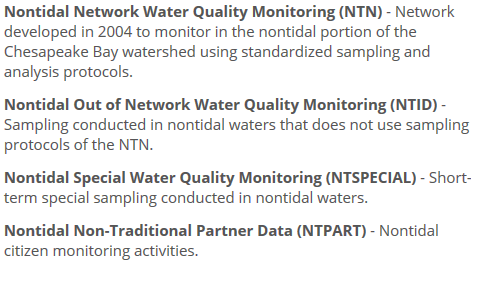

Below is the list of what biological/chemical parameters are measured by these stations. Source: [Chesapeak Bay WQ Data User Guide](https://www.chesapeakebay.net/documents/3676/wq_data_userguide_10feb12_mod.pdf), Pages 11-12 on PDF/Table 7.

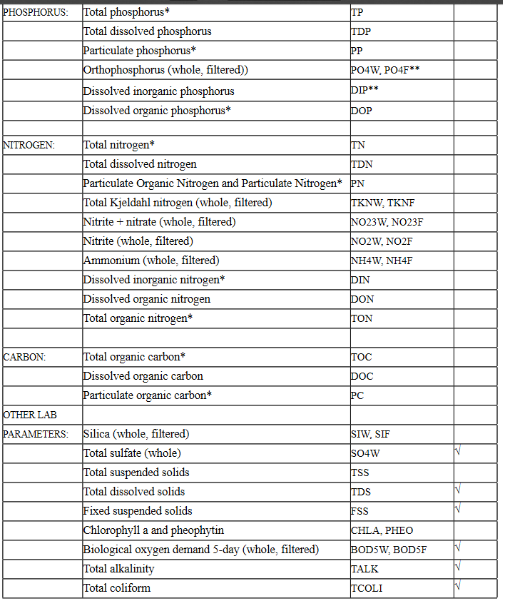

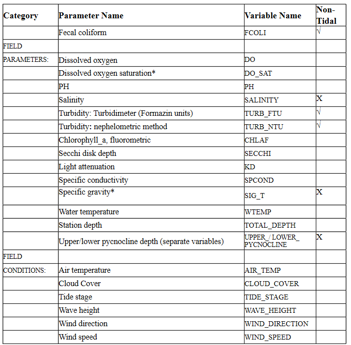

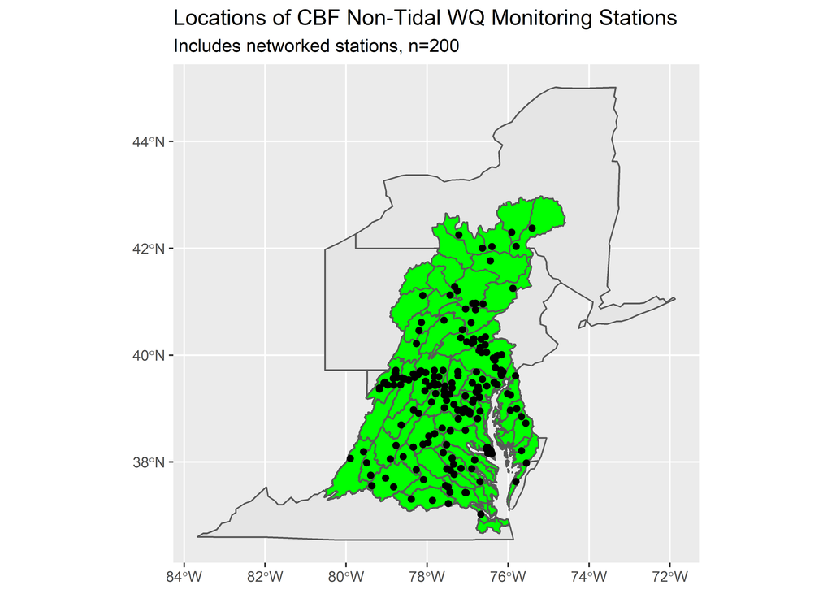

### USGS

The USGS data is taken from the [National Water Quality Monitoring Council Data Portal](https://www.waterqualitydata.us/portal/). This portal is a merger of 4 individual data sources:

- [BioData](https://aquatic.biodata.usgs.gov/landing.action)
- [National Water Information System (NWIS)](https://www.usgs.gov/nwis-national-water-information-system)
- STEWARDS
- [Storage and Retrieval for Water Quality Data (STORET)](https://www.epa.gov/waterdata/water-quality-data-wqx)

| MonitoringLocationTypeName | Count |
| --- | --- |
| Canal Drainage | 60 |
| Channelized Stream | 274101 |
| River/Stream | 1516880 |
| River/Stream Perennial | 25868 |
| Stream | 2921037 |
| Stream: Ditch | 2873 |
| Stream: Tidal stream | 35 |

These stations observe a wide range of sampling parameters. These are all the parameters a station has observed, along with the count and percentage of all stations that measure that specific parameter.

|  | CharacteristicName | num_stations | pct |
| --- | --- | --- | --- |
| 1 | (1R,2S,5R)-Menthol | 140 | 2.95305444968354e-05 |
| 2 | (E)-Dimethomorph | 1 | 2.10932460691681e-07 |
| 3 | (Z)-Dimethomorph | 1 | 2.10932460691681e-07 |
| 4 | .alpha.-Endosulfan | 181 | 3.81787753851943e-05 |
| 5 | .alpha.-HCH-d6 | 339 | 7.150610417448e-05 |
| 6 | .alpha.-Hexachlorocyclohexane | 356 | 7.50919560062385e-05 |
| 7 | .alpha.-Terpineol | 2 | 4.21864921383363e-07 |
| 8 | .beta.-Endosulfan | 35 | 7.38263612420884e-06 |
| 9 | .beta.-Hexachlorocyclohexane | 91 | 1.9194853922943e-05 |
| 10 | .beta.-Sitosterol | 140 | 2.95305444968354e-05 |

[output cut: 1955 more lines]

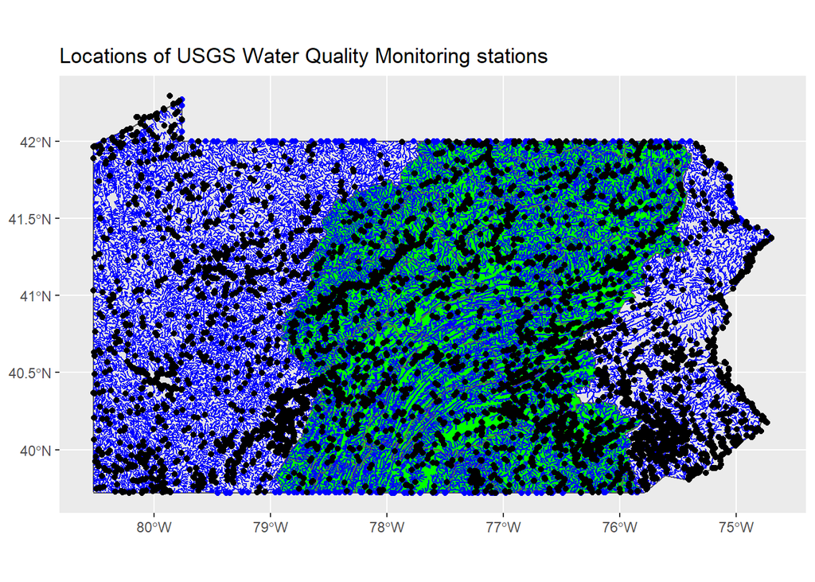